# Heterogeneous Treatment Effects of Intensive Glycemic Control on Kidney Microvascular Outcomes and Mortality in ACCORD: eGFR slopes

Vivek Charu, Jane W. Liang, Glenn M. Chertow, Zhuo Jun Li, Maria E. Montez-Rath, Pascal Geldsetzer, Ian H. de Boer, Lu Tian, and Manjula Kurella Tamura

2024-01-04

```r
library(tidyverse)
library(ggrepel)
library(nlme)
library(mvnfast)

library(foreach)
library(doParallel)

# Cluster object
cl = parallel::makeCluster(parallel::detectCores() - 2)
# Register parallel backend
registerDoParallel(cl)

# Set background to be white for all ggplots
theme_set(theme_classic())
```

## Data processing

We read in the data and extract the outcome and covariate variables of interest. Duplicate observations and observations where the treatment arm or variables needed to calculate the KFRE are missing are dropped.

```r
# Read in datasets
# Raw data
raw_data = read.csv("/Users/jliang/Library/CloudStorage/Box-Box/Jane-Vivek/ACCORD HTE Analysis/Data/New data 26SEP2022/accordall.csv", header = TRUE)

# Additional outcomes
other_df = read.csv("/Users/jliang/Library/CloudStorage/Box-Box/Jane-Vivek/ACCORD HTE Analysis/Data/ACCORD_GLY_NEWOUTCOMES-2.csv", header = TRUE)
hypo_df = read.csv("/Users/jliang/Library/CloudStorage/Box-Box/RELATE\ CKD/Study\ Datasets/ACCORD/ACCORD_2017b_2\ 2/Main_Study/3-Data_Sets-Analysis/3a-Analysis_Data_Sets/csv/hypoglycemiatime1st.csv")

# Concomitant medications
meds_df = read.csv("/Users/jliang/Library/CloudStorage/Box-Box/RELATE\ CKD/Study\ Datasets/ACCORD/ACCORD_2017b_2\ 2/Main_Study/3-Data_Sets-Analysis/3a-Analysis_Data_Sets/csv/concomitantmeds.csv")
# Classification groups for medication
meds_groups_df = read.csv("../Copy of Meds_ACCORD.csv")[,1:2]
names(meds_groups_df) = c("med", "group")


# Subset for death outcomes
other_df = other_df %>%
  select(maskid = id, ALLDEATH, alldeath_fu, CVDEATH, cvdeath_fu)
# Subset for 1st assisted hypoglycemic event
hypo_df = hypo_df %>%
  mutate(hypoglycemia = 1 - censor_any,
         hypoglycemia_fu = 365 * fuyrs_any) %>%
  select(maskid = MaskID, hypoglycemia, hypoglycemia_fu)

# Use friendlier variable names
meds_groups_df = meds_groups_df %>%
  filter(group != "") %>%
  mutate(group = recode(group, "anti-htn" = "anti_htn",
                        "chol lowering" = "chol_lowering",
                        "oral DM" = "oral_DM"))
# Convert data frame of classification groups to list
con_meds = sort(unique(meds_groups_df$group))
meds_groups_list = sapply(con_meds, function(x) {
  meds_groups_df$med[meds_groups_df$group == x]
})
# Only consider baseline meds
meds_df = meds_df %>% filter(Visit == "BLR")
# Create a new variable for each con med classification group
for (med in con_meds) {
  meds_df[[med]] =
    rowSums(meds_df[,meds_groups_list[[med]]], na.rm = TRUE) > 0
}


# Merge in death outcomes
raw_data = merge(raw_data, other_df, by = "maskid", all.x = TRUE)
# Merge in 1st assisted hypoglycemic event
raw_data = merge(raw_data, hypo_df, by = "maskid", all.x = TRUE)
# Merge in con meds
raw_data = merge(raw_data %>% select(!diuretic),
                 meds_df %>% select(maskid = MaskID, all_of(con_meds)),
                 by = "maskid", all.x = TRUE)

# Create composite kidney outcome
raw_data$neph_composite = pmax(raw_data$Neph2, raw_data$Neph3)
raw_data$neph_composite_fu = pmin(raw_data$Neph2Days, raw_data$Neph3Days)

# Quantitative variables to potentially include in the models
subset_quant = c("female", "baseline_age", "raceth",
                 "sbp", "dbp", "pulsepres",
                 "chol", "trig", "vldl", "ldl", "hdl",
                 "alt", "cpk",
                 "fpg", "hba1c",
                 "ualb", "ucreat", "uacr",
                 "ckd2021GFR", "screat",
                 "bmi",
                 "smokelif",
                 con_meds)

# List of outcome variables
outcome_list = list(
  neph_composite = c(status = "neph_composite", time = "neph_composite_fu"),
  Neph2 = c(status = "Neph2", time = "Neph2Days"),
  Neph3 = c(status = "Neph3", time = "Neph3Days"),
  ALLDEATH = c(status = "ALLDEATH", time = "alldeath_fu"),
  CVDEATH = c(status = "CVDEATH", time = "cvdeath_fu"),
  hypoglycemia = c(status = "hypoglycemia", time = "hypoglycemia_fu"))
# All outcomes
outcomes = unlist(outcome_list, use.names = FALSE)

# Race should be a factor
raw_data$raceth = as.factor(raw_data$raceth)

# Make relevant exclusions and define new dataset
df = raw_data %>%
  select(all_of(c("maskid", "glyarm", "kfrs", outcomes, subset_quant))) %>%
  drop_na(all_of(c("glyarm", "kfrs"))) %>% # Drop those with missing values
  unique() # Drop duplicates

# Include race contrasts
df = data.frame(df,
                raceth0 = ifelse(df$raceth == 0, 1, 0),
                model.matrix(~raceth, df)[,-1])
```

Read in the longitudinal lab data and calculate eGFR.

```r
# Read in data
dir = "/Users/jliang/Library/CloudStorage/Box-Box/RELATE\ CKD/Study\ Datasets/ACCORD/ACCORD_2017b_2\ 2/Main_Study/3-Data_Sets-Analysis/3a-Analysis_Data_Sets/csv/"
activitystatus = read.csv(paste0(dir, "activitystatus.csv"))
otherlabs = read.csv(paste0(dir, "otherlabs.csv"))
accord_key = read.csv(paste0(dir, "accord_key.csv"))

# Calculate eGFR
calc_eGFR = function(AGE, MALE, SCR) {
  if (length(AGE) !=  length(MALE) ||
      length(AGE) !=  length(SCR) ||
      length(MALE) !=  length(SCR)) {
    warning("Input arguments are not the same length.")
  }

  kau = 0.7*(1 - MALE) + 0.9*MALE
  alpha = -0.241*(1 - MALE) - 0.302*MALE
  beta = 1.012*(1 - MALE) + 1*MALE

  return(142 * pmin(SCR/kau, 1)^alpha * pmax(SCR/kau, 1)^(-1.2) *
           0.9938^AGE * beta)
}

# Combine otherlabs (contains serum creatinine) with activitystatus (contains
# FU time) and accord_key (contains age, sex, and arm)
# Calculate eGFR and 4-month spline
# Only include observations with 7 years and for IDs included in the main df
egfr_df = right_join(activitystatus %>% select(MaskID, Visit, days_from_baseline),
                     otherlabs %>% select(MaskID, Visit, screat, gfr),
                     by = c("MaskID", "Visit")) %>%
  left_join(accord_key %>%
              select(MaskID, female, baseline_age, raceclass, arm, treatment),
            by = "MaskID") %>%
  mutate(treat = ifelse(arm %in% c(3, 4, 7, 8), 1, 0),
         baseline_age = baseline_age + days_from_baseline / 365) %>%
  mutate(egfr = calc_eGFR(baseline_age, female == 0, screat),
         days_from_baseline_165 =
           ifelse(days_from_baseline >= 165, 165, days_from_baseline),
         spline =
           ifelse(days_from_baseline >= 165, days_from_baseline - 165, 0)) %>%
  filter(days_from_baseline <= 365*7,
         MaskID %in% df$maskid) %>%
  drop_na()
```

## Kidney failure risk equation (KFRE)

We calculate the 5-year predicted risk using the KFRE and define KFRE quartiles.

```r
# Calculate 5-year KFRE
df$kfre5 = with(df, {
  1 - 0.8996^exp(-0.2201 * (baseline_age/10 - 7.036) +
                   0.2467 * ((female==0) - 0.5642) -
                   0.5567 * (ckd2021GFR/5 - 7.222) +
                   0.4510 * ( log(uacr) - 5.137))
})

# kfre quartile thresholds
kfre_quart_thresh = quantile(df$kfre5, seq(0.25, 0.75, by = 0.25))
# Create groups based on thresholds
df$kfre_quarts = as.numeric(cut(df$kfre5,
                                breaks = c(-Inf, as.numeric(kfre_quart_thresh), Inf),
                                labels = c(1:(length(kfre_quart_thresh)+1))))

# Merge in KFRE quartiles to long eGFR data
egfr_df = left_join(egfr_df, df %>% select(maskid, kfre_quarts),
                    by = c("MaskID" = "maskid"))
```

## eGFR slopes

We fit linear mixed models to the entire longitudinal eGFR dataset and within each KFRE quartile. We include a spline term at 4 months that separates the eGFR slopes into acute (before 4 months) and chronoic (after 4 months) slopes. Interactions between acute/chronic slopes and treatment and random slopes for the chronic slope and chronic slope x treatment interaction are also included.

```r
# Fit linear mixed model to eGFR with random intercepts and slopes to all patients,
# Include spline at 4 months
fit_egfr = lme(egfr ~ days_from_baseline_165 * treat + spline * treat,
               data = egfr_df,
               random = ~ 1 + spline + spline:treat | MaskID)

# Fit linear mixed model to eGFR with random intercepts and slopes to all
# patients, within each KFRS quartile
# Include spline at 4 months
fit_egfr_kfre_quarts = lapply(1:4, function(i) {
  lme(egfr ~ days_from_baseline_165 * treat + spline * treat,
      data = egfr_df %>% filter(kfre_quarts == i),
      random = ~ 1 + spline + spline:treat | MaskID,
      control = lmeControl(opt = "optim", optimMethod = "L-BFGS-B"))
})

# Save model fits
save(fit_egfr, fit_egfr_kfre_quarts, file = "fit_egfr.rData")

# Graphical examination of model fit
# Models by quartile look similar
# I think these all look fine except for the tails of the Q-Q plot?
plot(fit_egfr)
plot(fit_egfr, MaskID ~ resid(.))
qqnorm(resid(fit_egfr))
```

Using the slope coefficients from the model fits, we can calculate the mean eGFR slopes for the treatment and control arms, and the difference between arms. The total slope is taken as a weighted average of the acute and chronic slopes.

```r
# Extract coefficients from linear mixed models
coef_egfr = do.call(rbind, lapply(1:4, function(i) {
  as.data.frame(cbind(kfre_quarts = i, coef(fit_egfr_kfre_quarts[[i]])))
}))

# eGFR slopes from models fit by quartile, estimated for each individual
slope_df = data.frame(
  maskid = as.numeric(rownames(coef_egfr)),
  egfr_slope = 365 * ((4/84) * coef_egfr$`days_from_baseline_165:treat` +
    (80/84) * coef_egfr$`treat:spline`)
)

# Merge eGFR slopes with data frame
df = left_join(df, slope_df, by = "maskid")

# Calculate overall eGFR slope difference
overall_egfr = mean(df$egfr_slope)

# Calculate eGFR slope difference for each quartile
kfre_quart_egfr = sapply(1:4, function(i) {
  df_sub = df[df$kfre_quarts == i,]
  mean(df_sub$egfr_slope)
})

# Treatment and control slopes (eGFR decline per year)
egfr_lm_coefs = rbind(coef_egfr %>% mutate(kfre_quarts = "Overall"), coef_egfr) %>%
  mutate(Quartile = factor(kfre_quarts, levels = c("Overall", 1:4))) %>%
  group_by(Quartile) %>%
  summarize(
    Treatment = mean(365 * ((4/84) * (days_from_baseline_165 + `days_from_baseline_165:treat`) +
                    (80/84) * (spline + `treat:spline`))),
    Control = mean(365 * ((4/84) * days_from_baseline_165 + (80/84) * spline)),
    Treatment_Spline = mean(spline + `treat:spline`),
    Control_Spline = mean(spline),
    Treatment_Slope = mean(days_from_baseline_165 + `days_from_baseline_165:treat`),
    Control_Slope = mean(days_from_baseline_165),
    Treatment_Intercept = mean(`(Intercept)` + treat),
    Control_Intercept = mean(`(Intercept)`)) %>%
  ungroup()
egfr_lm_coefs %>%
  select(Quartile, Treatment, Control)
```

```
## # A tibble: 5 × 3
##   Quartile Treatment Control
##   <fct>        <dbl>   <dbl>
## 1 Overall      -1.81   -2.18
## 2 1            -1.79   -2.09
## 3 2            -2.25   -2.57
## 4 3            -1.81   -2.21
## 5 4            -1.38   -1.84
```

We summarize the number of observations/participants collected at each time point.

```r
# Table with number of observations for each visit
rbind(
  egfr_df %>%
    filter(Visit != "EXIT") %>%
    mutate(Months = case_when(Visit == "BLR" ~ 0,
                              TRUE ~ as.numeric(substr(Visit, 2, 3))),
           kfre_quarts = "0_Overall"),
  egfr_df %>%
    filter(Visit != "EXIT") %>%
    mutate(Months = case_when(Visit == "BLR" ~ 0,
                              TRUE ~ as.numeric(substr(Visit, 2, 3))))) %>%
  group_by(Months, treat, kfre_quarts) %>%
  summarize(n = n()) %>%
  ungroup() %>%
  pivot_wider(names_from = c(kfre_quarts, treat),
              values_from = n, names_sort = TRUE) %>%
  column_to_rownames("Months") %>%
  t() %>%
  `rownames<-`(paste0(c(rep("Overall", 2), paste0("Q", rep(1:4, each = 2))),
                     rep(c(" (Control)", " (Treatment)"))))
```

```
##                        0    4    8   12   16   20   24   28   32   36   40   44
## Overall (Control)   4873 4656 3969 4572 1627 1789 4432 2026 2006 4263 1977 1845
## Overall (Treatment) 4904 4651 3930 4562 1599 1810 4404 1968 1965 4208 1941 1809
## Q1 (Control)        1231 1183 1068 1169  439  481 1124  540  527 1083  527  462
## Q1 (Treatment)      1214 1156 1046 1133  425  476 1096  517  518 1056  521  469
## Q2 (Control)        1255 1203 1056 1182  452  487 1146  541  536 1116  529  494
## Q2 (Treatment)      1189 1126  991 1120  404  456 1081  511  501 1039  497  472
## Q3 (Control)        1194 1140  947 1112  397  448 1078  508  510 1040  496  467
## Q3 (Treatment)      1250 1195  999 1158  418  480 1126  524  523 1074  512  465
## Q4 (Control)        1193 1130  898 1109  339  373 1084  437  433 1024  425  422
## Q4 (Treatment)      1251 1174  894 1151  352  398 1101  416  423 1039  411  403
##                       48   52   56   60  64  68  72  76  80  84
## Overall (Control)   3313 1391 1207 1906 758 518 495 241 245 174
## Overall (Treatment) 3259 1336 1170 1864 715 493 502 234 219 167
## Q1 (Control)         831  334  271  444 167 112  71  31  34  24
## Q1 (Treatment)       795  298  257  395 128  81  61  26  25  18
## Q2 (Control)         850  352  303  466 173 119  94  50  51  36
## Q2 (Treatment)       806  342  286  443 166 112  84  42  39  31
## Q3 (Control)         806  358  324  491 227 144 141  70  72  47
## Q3 (Treatment)       826  351  320  499 201 126 128  55  50  49
## Q4 (Control)         826  347  309  505 191 143 189  90  88  67
## Q4 (Treatment)       832  345  307  527 220 174 229 111 105  69
```

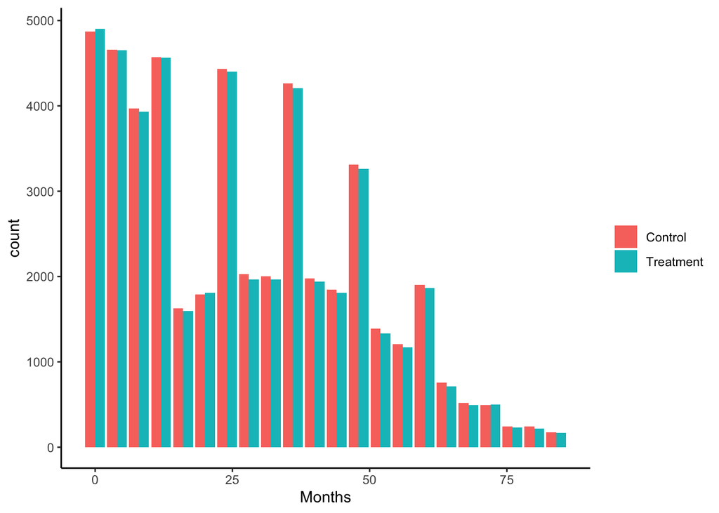

```r
# Overall
egfr_df %>%
  filter(Visit != "EXIT") %>%
  mutate(Months = case_when(Visit == "BLR" ~ 0,
                            TRUE ~ as.numeric(substr(Visit, 2, 3)))) %>%
  ggplot(aes(x =  Months, fill = as.factor(treat))) +
  geom_bar(position="dodge") +
  scale_fill_discrete(name = "", labels = c("0" = "Control", "1" = "Treatment"))
```

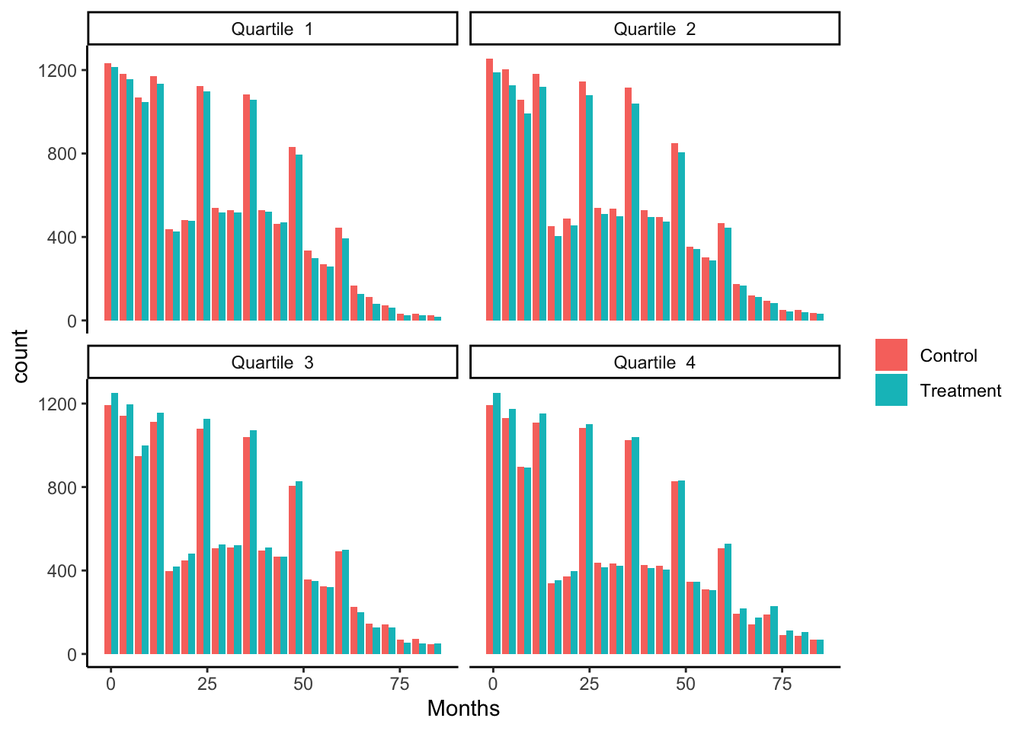

```r
# By quartile
egfr_df %>%
  filter(Visit != "EXIT") %>%
  mutate(Months = case_when(Visit == "BLR" ~ 0,
                            TRUE ~ as.numeric(substr(Visit, 2, 3))),
         kfre_quarts = paste("Quartile ", kfre_quarts)) %>%
  ggplot(aes(x =  Months, fill = as.factor(treat))) +
  geom_bar(position="dodge") +
  scale_fill_discrete(name = "", labels = c("0" = "Control", "1" = "Treatment")) +
  facet_wrap(~kfre_quarts)
```

We use a parametric bootstrap approach where we repeatedly sample fixed and random effects from multivariate normal distributions (based on the estimates/covariances from the fitted model) to reconstruct a sample of slopes.

```r
# Number of bootstraps
B = 1000

# Number of people in each quartile
n_kfre_quarts = as.numeric(table(df$kfre_quarts))
# Fixed effect estimates
fixed_eff = lapply(fit_egfr_kfre_quarts, fixed.effects)
# Fixed and random covariance matrices
fixed_cov_mat = lapply(fit_egfr_kfre_quarts, vcov)
random_cov_mat = lapply(fit_egfr_kfre_quarts, getVarCov)

boot_kfre_egfr = foreach::foreach(
  b = 1:B, .packages = c("tidyverse", "mvnfast")
  ) %dopar% {
    # Set seed
    set.seed(b)

    # Get data frame of slopes for each quartile
    slopes_by_quart = do.call(
      rbind,
      lapply(1:4, function(i) {
        # Randomly generate slopes by sampling from MVN
        n = n_kfre_quarts[i]
        fixed_samp = rmvn(n, mu = fixed_eff[[i]], sigma = fixed_cov_mat[[i]])
        colnames(fixed_samp) = names(fixed_eff[[i]])
        random_samp = rmvn(n, mu = rep(0, ncol(random_cov_mat[[i]])),
                           sigma = random_cov_mat[[i]])
        colnames(random_samp) = colnames(random_cov_mat[[i]])

        # Data frame of treatment/control slopes and slope difference
        data.frame(
          kfre_quarts = i,
          egfr_slope =
            365 * ((4/84) * fixed_samp[,"days_from_baseline_165:treat"] +
                     (80/84) * (fixed_samp[,"treat:spline"] + random_samp[,"spline:treat"])),
          Treatment = 365 * ((4/84) * (fixed_samp[,"days_from_baseline_165"] +
                                        fixed_samp[,"days_from_baseline_165:treat"]) +
                      (80/84) * (fixed_samp[,"spline"] + random_samp[,"spline"] +
                                   fixed_samp[,"treat:spline"] + random_samp[,"spline:treat"])),
          Control = 365 * ((4/84) * fixed_samp[,"days_from_baseline_165"] +
                             (80/84) * (fixed_samp[,"spline"] + random_samp[,"spline"]))
        )
    }))

    # Calculate overall slope_df slope difference
    overall_egfr = mean(slopes_by_quart$egfr_slope)

    # Calculate eGFR slope difference for each quartile
    kfre_quart_egfr = tapply(slopes_by_quart$egfr_slope,
                             slopes_by_quart$kfre_quarts, mean)

    # Slope for each treatment arm  and quartile (used for plotting)
    egfr_lm_coefs = rbind(slopes_by_quart %>% mutate(kfre_quarts = "Overall"),
                          slopes_by_quart) %>%
      mutate(Quartile = factor(kfre_quarts, levels = c("Overall", 1:4))) %>%
      group_by(Quartile) %>%
      summarize(
        Treatment = mean(Treatment),
        Control = mean(Control)) %>%
      ungroup()

    return(list(overall_egfr = overall_egfr,
                kfre_quart_egfr = kfre_quart_egfr,
                egfr_lm_coefs = egfr_lm_coefs))
  }
```

We plot the eGFR trajectories over time in the treatment and control arms.

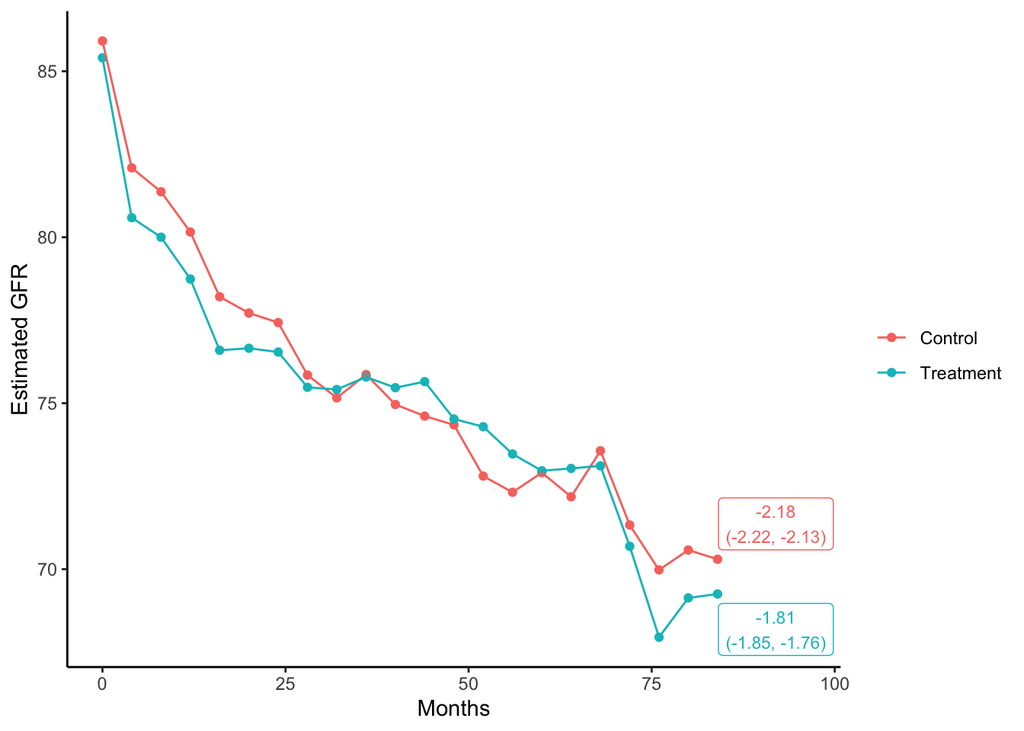

```r
# Extract bootstrap treatment and control arm slope estimates
boot_egfr_lm_coefs = abind::abind(lapply(boot_kfre_egfr, function(x) {
  x$egfr_lm_coefs[,-1]
}), along = 3)

# Add bootstrap CIs for treatment and control slopes
egfr_lm_coefs = cbind(
  egfr_lm_coefs,
  data.frame( apply(boot_egfr_lm_coefs, c(1,2), quantile, 0.025, na.rm = TRUE)) %>%
    setNames(paste0(c("Treatment", "Control"), "_lo")),
  data.frame( apply(boot_egfr_lm_coefs, c(1,2), quantile, 0.975, na.rm = TRUE)) %>%
    setNames(paste0(c("Treatment", "Control"), "_hi"))) %>%
  mutate(treatment_label = paste0(round(Treatment, 2), "\n(",
                                  round(Treatment_lo, 2), ", ",
                                  round(Treatment_hi, 2), ")"),
         control_label = paste0(round(Control, 2), "\n(",
                                round(Control_lo, 2), ", ",
                                round(Control_hi, 2), ")"))

# Overall
egfr_df %>%
  filter(Visit != "EXIT") %>%
  mutate(Months = case_when(Visit == "BLR" ~ 0,
                            TRUE ~ as.numeric(substr(Visit, 2, 3)))) %>%
  group_by(Months, treat) %>%
  summarize(egfr = mean(egfr)) %>%
  ungroup() %>%
  mutate(slope_label =
           c(rep(NA, 2*(length(unique(egfr_df$Visit))-2)),
             egfr_lm_coefs$control_label[1], egfr_lm_coefs$treatment_label[1])) %>%
  ggplot(aes(x = Months, y = egfr, color = as.factor(treat))) +
  geom_point() + geom_line() +
  geom_label_repel(aes(label = slope_label), size = 3,
                   nudge_x = 12, show.legend = FALSE,
                   na.rm = TRUE, segment.color = "transparent") +
  scale_color_discrete(name = "", labels = c("0" = "Control", "1" = "Treatment")) +
  ylab("Estimated GFR")
```

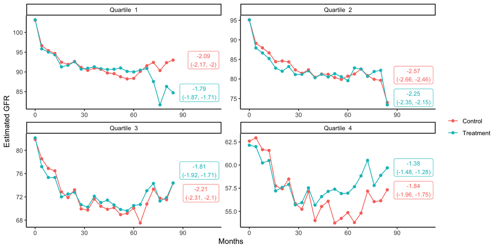

```r
# By quartile
egfr_df %>%
  filter(Visit != "EXIT") %>%
  mutate(Months = case_when(Visit == "BLR" ~ 0,
                            TRUE ~ as.numeric(substr(Visit, 2, 3)))) %>%
  group_by(Months, treat, kfre_quarts) %>%
  summarize(egfr = mean(egfr)) %>%
  ungroup() %>%
  mutate(kfre_quarts = paste("Quartile ", kfre_quarts),
         slope_label =
           c(rep(NA, 4*2*(length(unique(egfr_df$Visit))-2)),
             egfr_lm_coefs$control_label[-1], egfr_lm_coefs$treatment_label[-1])) %>%
  ggplot(aes(x = Months, y = egfr, color = as.factor(treat))) +
  geom_point() + geom_line() +
  geom_label_repel(aes(label = slope_label), size = 3,
                   nudge_x = 24,  show.legend = FALSE,
                   na.rm = TRUE, segment.color = "transparent") +
  scale_color_discrete(name = "", labels = c("0" = "Control", "1" = "Treatment")) +
  ylab("Estimated GFR") +
  facet_wrap(~kfre_quarts, scales = "free")
```

These are the same plots, but with 95% normal approximation CIs and the fitted regression line shown, instead of lines connecting the points.

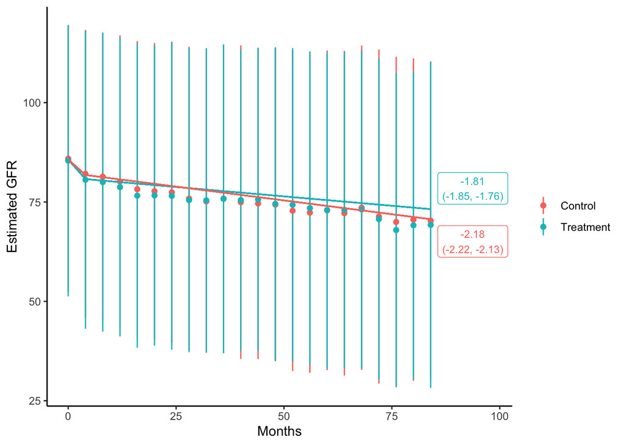

```r
# Overall
egfr_df %>%
  filter(Visit != "EXIT") %>%
  mutate(Months = case_when(Visit == "BLR" ~ 0,
                            TRUE ~ as.numeric(substr(Visit, 2, 3)))) %>%
  group_by(Months, treat) %>%
  summarize(egfr_mean = mean(egfr),
            egfr_se = sd(egfr, na.rm = TRUE)) %>%
  ungroup() %>%
  ggplot(aes(x = Months, y = egfr_mean, color = as.factor(treat))) +
  geom_pointrange(aes(ymin = egfr_mean - 1.96*egfr_se,
                      ymax = egfr_mean + 1.96*egfr_se), size = 0.25) +
  # Treatment spline
  geom_segment(aes(x = 0, xend = 4,
                   y = egfr_lm_coefs$Treatment_Intercept[1],
                   yend = egfr_lm_coefs$Treatment_Intercept[1] +
                     4*30 * egfr_lm_coefs$Treatment_Slope[1],
                   color = "1"), show.legend = FALSE) +
  geom_segment(aes(x = 4, xend = 84,
                   y = egfr_lm_coefs$Treatment_Intercept[1] +
                     4*30 * egfr_lm_coefs$Treatment_Slope[1],
                   yend = egfr_lm_coefs$Treatment_Intercept[1] +
                     4*30 * egfr_lm_coefs$Treatment_Slope[1] +
                     80*30 * egfr_lm_coefs$Treatment_Spline[1],
                   color = "1"), show.legend = FALSE) +
  # Control spline
  geom_segment(aes(x = 0, xend = 4,
                   y = egfr_lm_coefs$Control_Intercept[1],
                   yend = egfr_lm_coefs$Control_Intercept[1] +
                     4*30 * egfr_lm_coefs$Control_Slope[1],
                   color = "0"), show.legend = FALSE) +
  geom_segment(aes(x = 4, xend = 84,
                   y = egfr_lm_coefs$Control_Intercept[1] +
                     4*30 * egfr_lm_coefs$Control_Slope[1],
                   yend = egfr_lm_coefs$Control_Intercept[1] +
                     4*30 * egfr_lm_coefs$Control_Slope[1] +
                     80*30 * egfr_lm_coefs$Control_Spline[1],
                   color = "0"), show.legend = FALSE) +
  geom_label_repel(aes(x = x, y = y, label = slope_label),
                   data = data.frame(
                     x = rep(90, 2),
                     y = c(egfr_lm_coefs$Control_Intercept[1] +
                             7 * egfr_lm_coefs$Control[1],
                           egfr_lm_coefs$Treatment_Intercept[1] +
                             7 * egfr_lm_coefs$Treatment[1]),
                     treat = c(0, 1),
                     slope_label = c(egfr_lm_coefs$control_label[1],
                                     egfr_lm_coefs$treatment_label[1])),
                   size = 3, nudge_x = 8, direction = "y", show.legend = FALSE,
                   na.rm = TRUE, segment.color = "transparent") +
  scale_color_discrete(name = "", labels = c("0" = "Control", "1" = "Treatment")) +
  ylab("Estimated GFR")
```

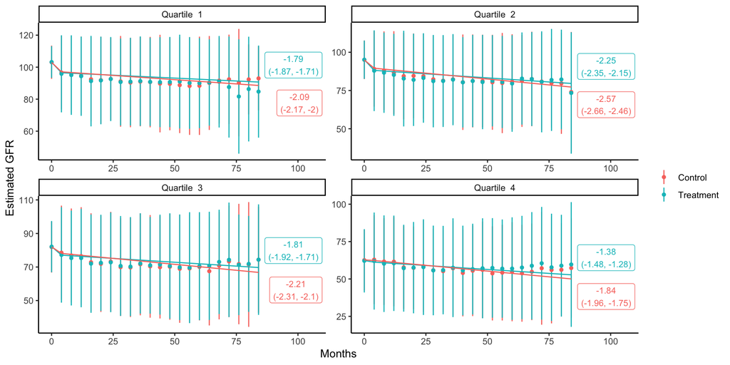

```r
# By quartile
egfr_df %>%
  filter(Visit != "EXIT") %>%
  mutate(Months = case_when(Visit == "BLR" ~ 0,
                            TRUE ~ as.numeric(substr(Visit, 2, 3)))) %>%
  group_by(Months, treat, kfre_quarts) %>%
  summarize(egfr_mean = mean(egfr),
            egfr_se = sd(egfr, na.rm = TRUE)) %>%
  ungroup() %>%
  mutate(kfre_quarts = paste("Quartile ", kfre_quarts)) %>%
  ggplot(aes(x = Months, y = egfr_mean, color = as.factor(treat))) +
  geom_pointrange(aes(ymin = egfr_mean - 1.96*egfr_se,
                      ymax = egfr_mean + 1.96*egfr_se), size = 0.15) +
  # Treatment spline
  geom_segment(aes(x = 0, xend = 4,
                   y = Treatment_Intercept,
                   yend = Treatment_Intercept +
                     4*30 * Treatment_Slope,
                   color = "1"),
               data = egfr_lm_coefs[-1,] %>%
                 mutate(kfre_quarts = paste("Quartile ", Quartile)),
               show.legend = FALSE) +
  geom_segment(aes(x = 4, xend = 84,
                   y = Treatment_Intercept +
                     4*30 * Treatment_Slope,
                   yend = Treatment_Intercept +
                     4*30 * Treatment_Slope +
                     80*30 * Treatment_Spline,
                   color = "1"),
               data = egfr_lm_coefs[-1,] %>%
                 mutate(kfre_quarts = paste("Quartile ", Quartile)),
               show.legend = FALSE) +
  # Control spline
  geom_segment(aes(x = 0, xend = 4,
                   y = Control_Intercept,
                   yend = Control_Intercept +
                     4*30 * Control_Slope,
                   color = "0"),
               data = egfr_lm_coefs[-1,] %>%
                 mutate(kfre_quarts = paste("Quartile ", Quartile)),
               show.legend = FALSE) +
  geom_segment(aes(x = 4, xend = 84,
                   y = Control_Intercept +
                     4*30 * Control_Slope,
                   yend = Control_Intercept +
                     4*30 * Control_Slope +
                     80*30 * Control_Spline,
                   color = "0"),
               data = egfr_lm_coefs[-1,] %>%
                 mutate(kfre_quarts = paste("Quartile ", Quartile)),
               show.legend = FALSE) +
  geom_label_repel(aes(x = x, y = y, label = slope_label),
                   data = data.frame(
                     x = rep(90, 2*4),
                     y = c(egfr_lm_coefs$Control_Intercept[-1] +
                             7 * egfr_lm_coefs$Control[-1],
                           egfr_lm_coefs$Treatment_Intercept[-1] +
                             7 * egfr_lm_coefs$Treatment[-1]),
                     treat = rep(c(0, 1), each = 4),
                     kfre_quarts = rep(paste("Quartile ", 1:4), 2),
                     slope_label = c(egfr_lm_coefs$control_label[-1],
                                     egfr_lm_coefs$treatment_label[-1])),
                   size = 3, nudge_x = 16, direction = "y", show.legend = FALSE,
                   na.rm = TRUE, segment.color = "transparent") +
  scale_color_discrete(name = "", labels = c("0" = "Control", "1" = "Treatment")) +
  ylab("Estimated GFR") +
  facet_wrap(~kfre_quarts, scales = "free")
```

Tables of the eGFR slope differences and normalized eGFR slope differences (where the overall eGFR slope difference is subtracted from each quartile’s estimate) with 95% bootstrap CIs are shown below.

```r
# Overall
kfre_overall_egfr_boot_ci = quantile(
  sapply(boot_kfre_egfr, function(x){
    x$overall_egfr
  }), c(0.025, 0.975))

# Not normalized
kfre_quart_egfr_boot_ci = sapply(1:4, function(i){
  quantile(sapply(boot_kfre_egfr, function(x){
    x$kfre_quart_egfr[i]
  }), c(0.025, 0.975))
})

# Make tables
kfre_quart_egfr_boot_tabs = rbind(
    data.frame(Quartile = "Overall",
               "Est" = overall_egfr,
               t(kfre_overall_egfr_boot_ci)),
    data.frame(Quartile = 1:4,
               "Est" = kfre_quart_egfr,
               t(kfre_quart_egfr_boot_ci)))

# Format table for printing
egfr_tab = kfre_quart_egfr_boot_tabs
rownames(egfr_tab) = NULL
names(egfr_tab) = c("Quartile", "Est", "2.5%", "97.5%")
egfr_tab[,c("Est", "2.5%", "97.5%")] =
  round(egfr_tab[,c("Est", "2.5%", "97.5%")], 5)
egfr_tab
```

```
##   Quartile     Est    2.5%   97.5%
## 1  Overall 0.36755 0.31839 0.41580
## 2        1 0.29637 0.19992 0.38540
## 3        2 0.32023 0.21316 0.42172
## 4        3 0.39201 0.28816 0.48703
## 5        4 0.46164 0.35599 0.57080
```

```r
# Normalized (subtract overall eGFR slope difference)
kfre_quart_egfr_norm_boot_ci = sapply(1:4, function(i){
  quantile(sapply(boot_kfre_egfr, function(x){
    x$kfre_quart_egfr[i] - x$overall_egfr
  }), c(0.025, 0.975))
})

# Make tables
kfre_quart_egfr_boot_norm_tabs =
  data.frame(Quartile = 1:4,
               "Est" = kfre_quart_egfr - overall_egfr,
               t(kfre_quart_egfr_norm_boot_ci))

# Format table for printing
egfr_norm_tab = kfre_quart_egfr_boot_norm_tabs
rownames(egfr_norm_tab) = NULL
names(egfr_norm_tab) = c("Quartile", "Est", "2.5%", "97.5%")
egfr_norm_tab[,c("Est", "2.5%", "97.5%")] =
  round(egfr_norm_tab[,c("Est", "2.5%", "97.5%")], 5)
egfr_norm_tab
```

```
##   Quartile      Est     2.5%   97.5%
## 1        1 -0.07118 -0.14896 0.01408
## 2        2 -0.04733 -0.13648 0.04310
## 3        3  0.02446 -0.06272 0.11011
## 4        4  0.09408  0.00686 0.18729
```

These are plots of the eGFR slope differences, with a horizontal reference line drawn at the overall/ATE point estimate. Shading denotes the ATE CI.

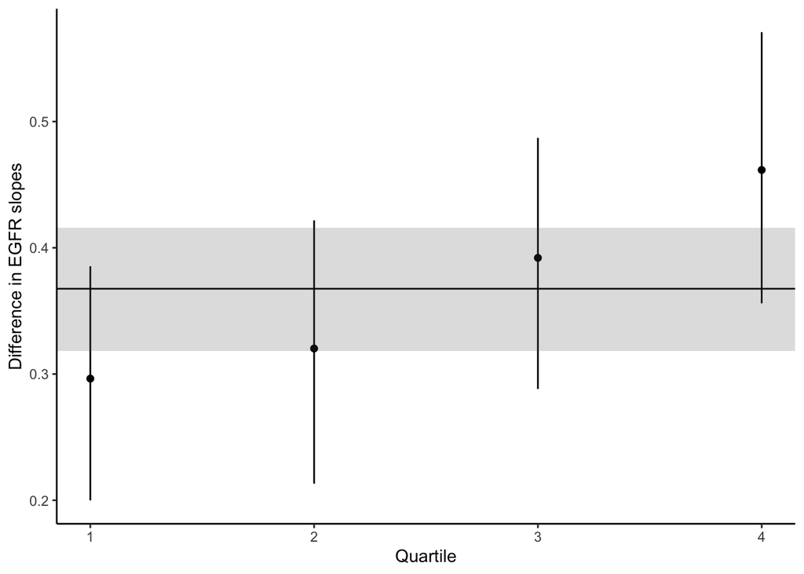

```r
kfre_quart_egfr_boot_tabs[-1,] %>%
  mutate(x = 1:4) %>%
  ggplot(aes(x = x, y = as.numeric(Est))) +
  geom_pointrange(aes(ymin = X2.5., ymax = X97.5.), size = 0.25) +
  geom_hline(data = kfre_quart_egfr_boot_tabs[1,], aes(yintercept = Est)) +
  geom_rect(data = kfre_quart_egfr_boot_tabs[1,],
            aes(x = NULL,y = NULL,
                xmin = -Inf, xmax = Inf,
                ymin = X2.5., ymax = X97.5.),
            alpha = 0.2) +
  theme(legend.position = 'bottom', legend.box = 'vertical') +
  xlab("Quartile") + ylab("Difference in EGFR slopes")
```

Normalized eGFR slope differences.

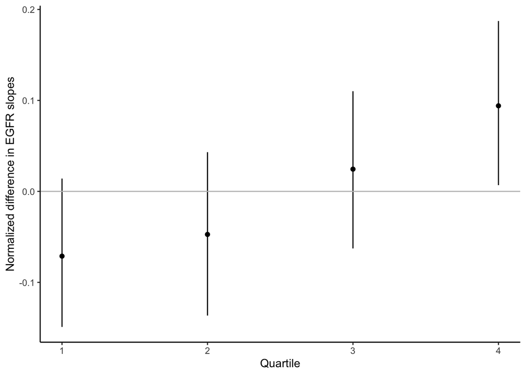

```r
kfre_quart_egfr_boot_norm_tabs %>%
    mutate(x = 1:4) %>%
    ggplot(aes(x = x, y = as.numeric(Est))) +
    geom_pointrange(aes(ymin = X2.5., ymax = X97.5.), size = 0.25) +
    theme(legend.position = 'bottom', legend.box = 'vertical') +
    xlab("Quartile") + ylab("Normalized difference in EGFR slopes") +
    geom_hline(yintercept = 0, color = "grey")
```